# Portfolio Computational Musicology

[figure not shown]

[figure not shown]

[figure not shown]

[figure not shown]

[figure not shown]

[figure not shown]

[figure not shown]

[figure not shown]

# Introduction

### AI is gradually taking over the world, including the music industry. When it comes to music production, the possibilities are endless—different genres, tempos, melodies, everything. That might be what makes it so exciting. What if a corpus was created to compare just how different all these various pieces of music really are?

The purpose

### Students of the course Computational Musicology were asked to make two tracks either using AI or composing their own. All these tracks were put in a corpus, which is used in this portfolio.

The corpus

### This portfolio was made for the course Computational Musicology at the UvA and is made by Ellen Rosmalen.

The portfolio

# Visualisations

### Arousal, Valence, Tempo, Instrumentalness; which has which?

[interactive chart not shown]

### Chromagrams of Lo’s and Reinouts track

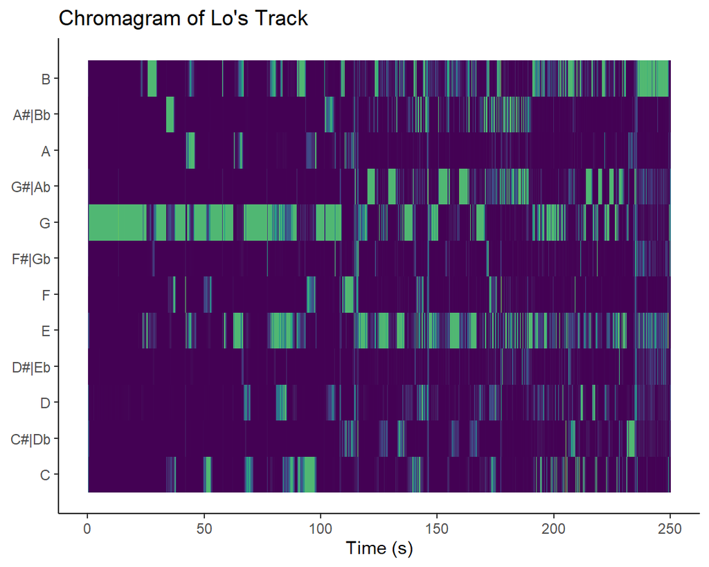

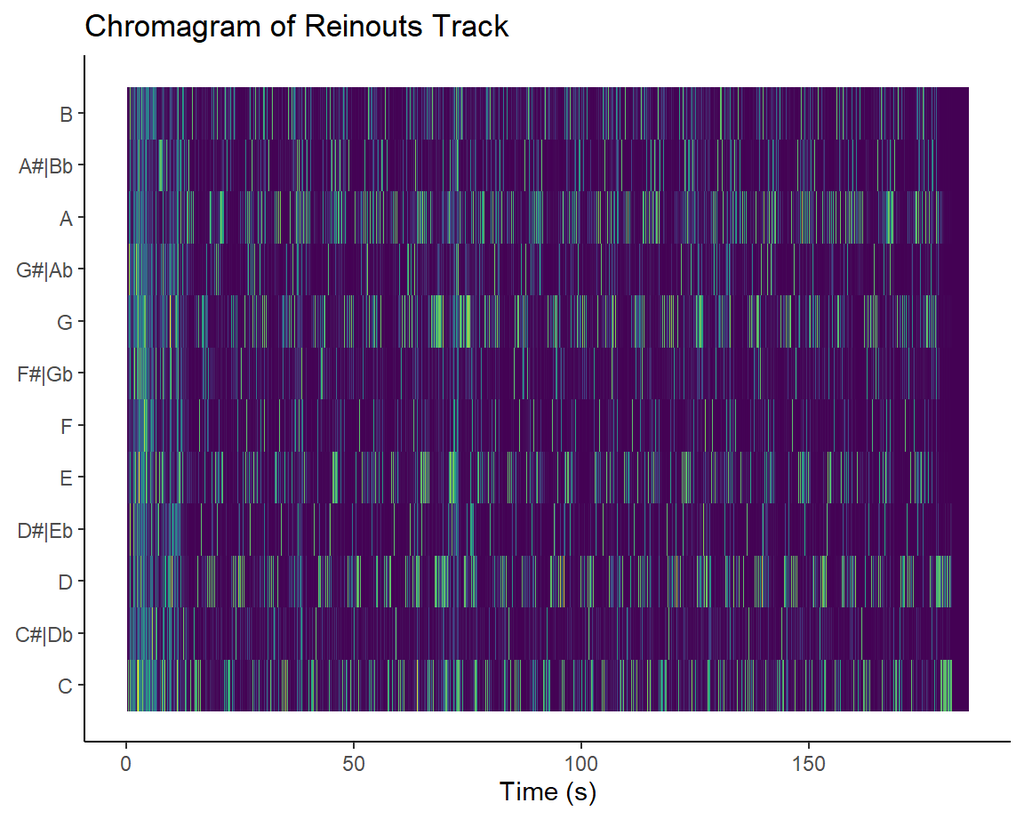

These chromagrams represent the intensity of different pitch classes over time. This visualization highlights the harmonic content of the track, showing which notes are most prominent at each moment. Patterns in the chromagram indicate key changes, chord progressions, or repeating harmonic structures. While the track of Lo is mostly in pitch class G, the track of reinout does not cointain a certain pitchclass.

### Self-similarity matrix based on chroma of Lo’s and Reinouts track

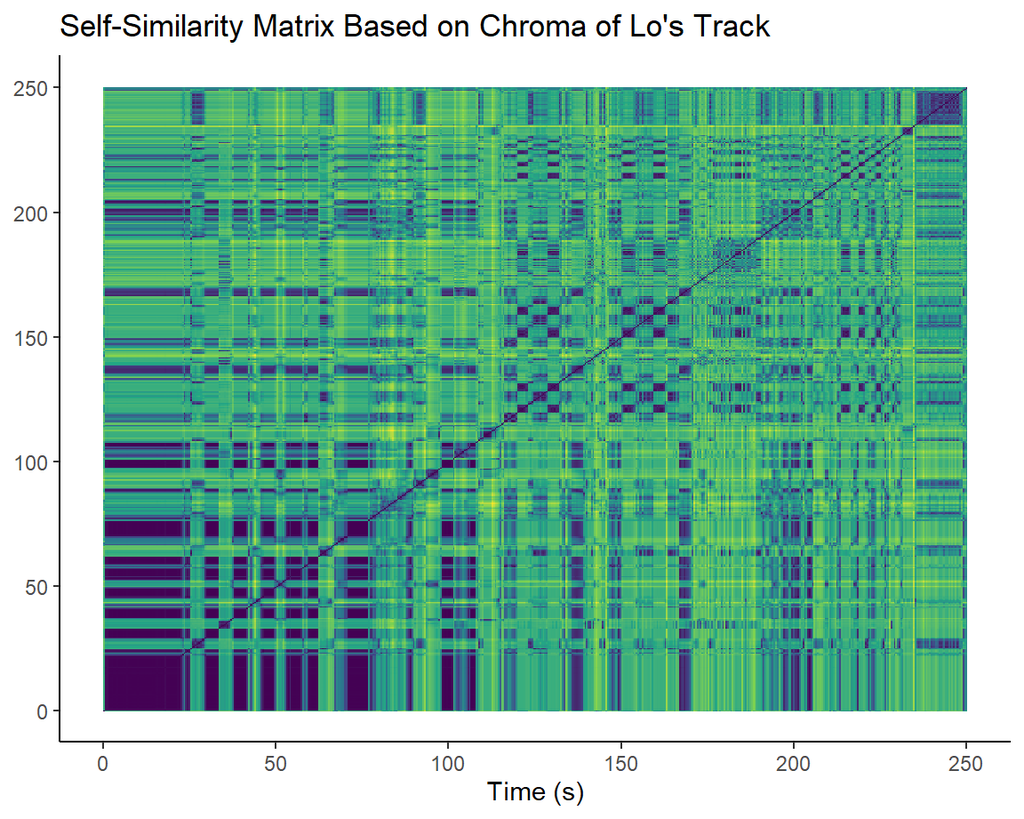

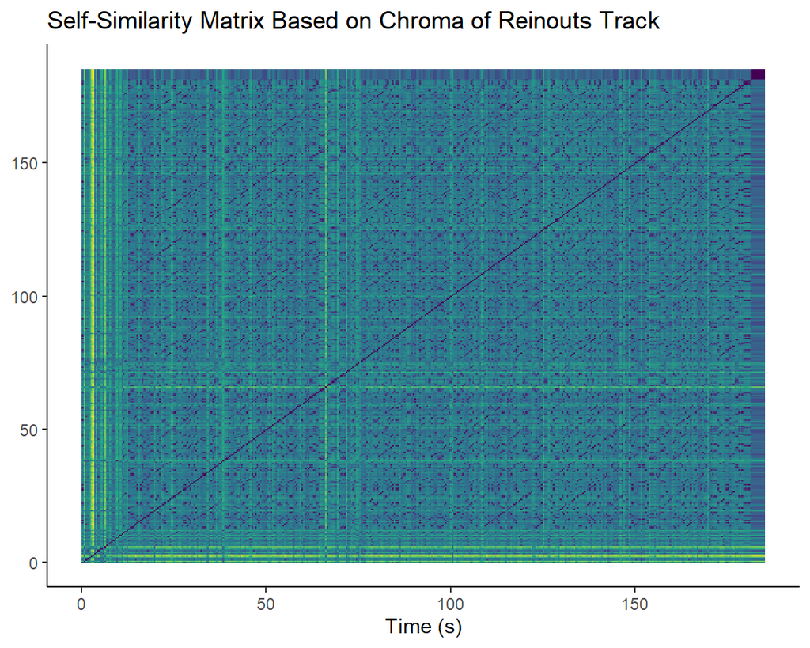

These self-similarity matrix’ are based on chroma features. This matrix reveals structural characteristics of the track by comparing its harmonic content over time. A strong diagonal line indicates perfect self-similarity, meaning the music remains consistent over time. Additionally, block-like patterns suggest recurring sections, such as verses and choruses, while grid-like formations may be linked to rhythmic consistency or percussive elements. The track of Lo gives a beautiful grid-pattern, in contrary to the track of Reinout. The mix of bright and dark regions suggests variations in melodic or harmonic content, meaning the song follows a structured composition with repeated themes and distinct transitions, which is not the case with the track of Reinout. The matrix of Reinouts track indicates a lot of changes continuously without repeating motifs or sections.

### self-similarity matrix based on timbre of Lo’s and Reinouts track

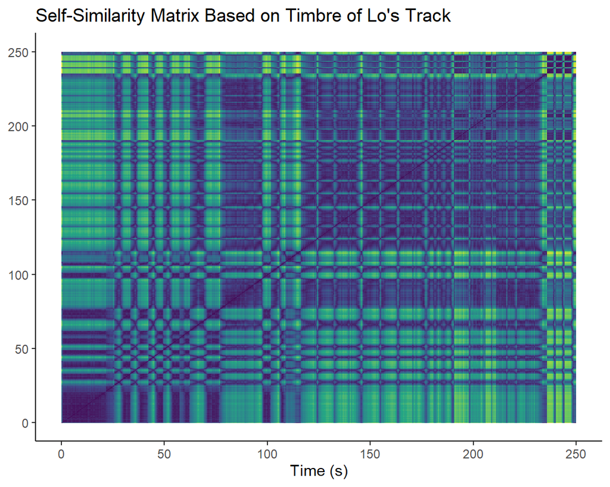

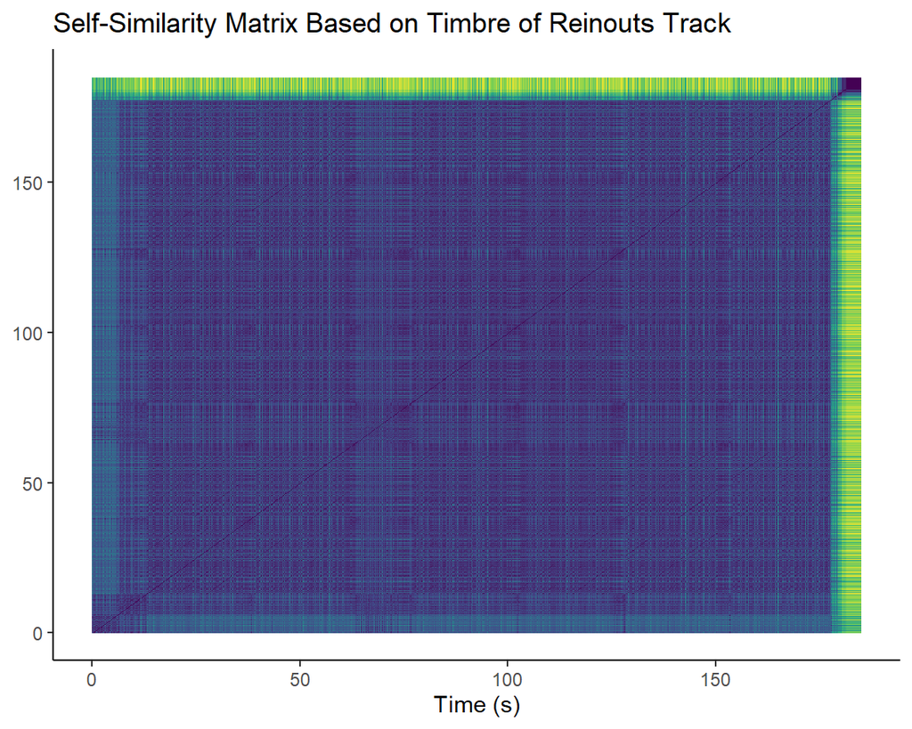

### Chordograms of Lo’s and Reinouts track

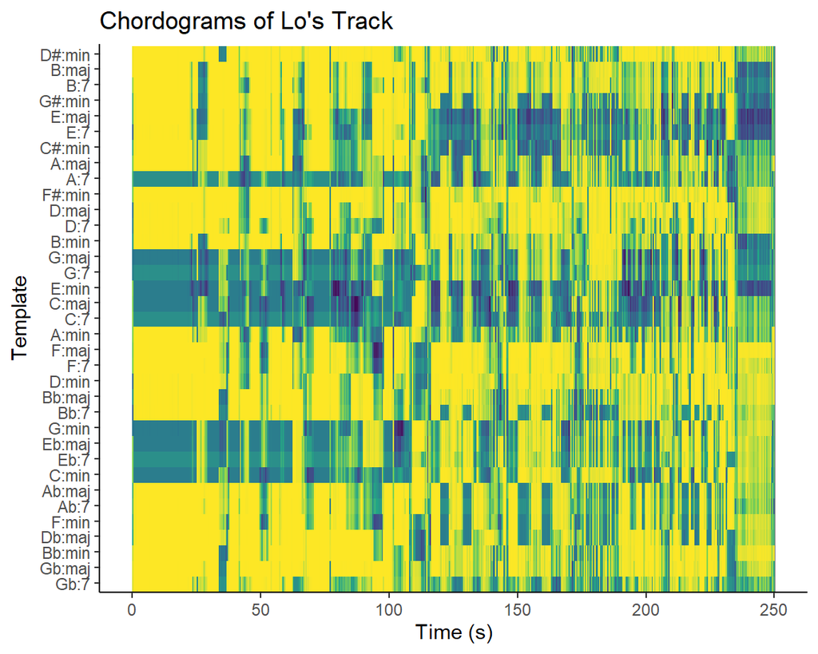

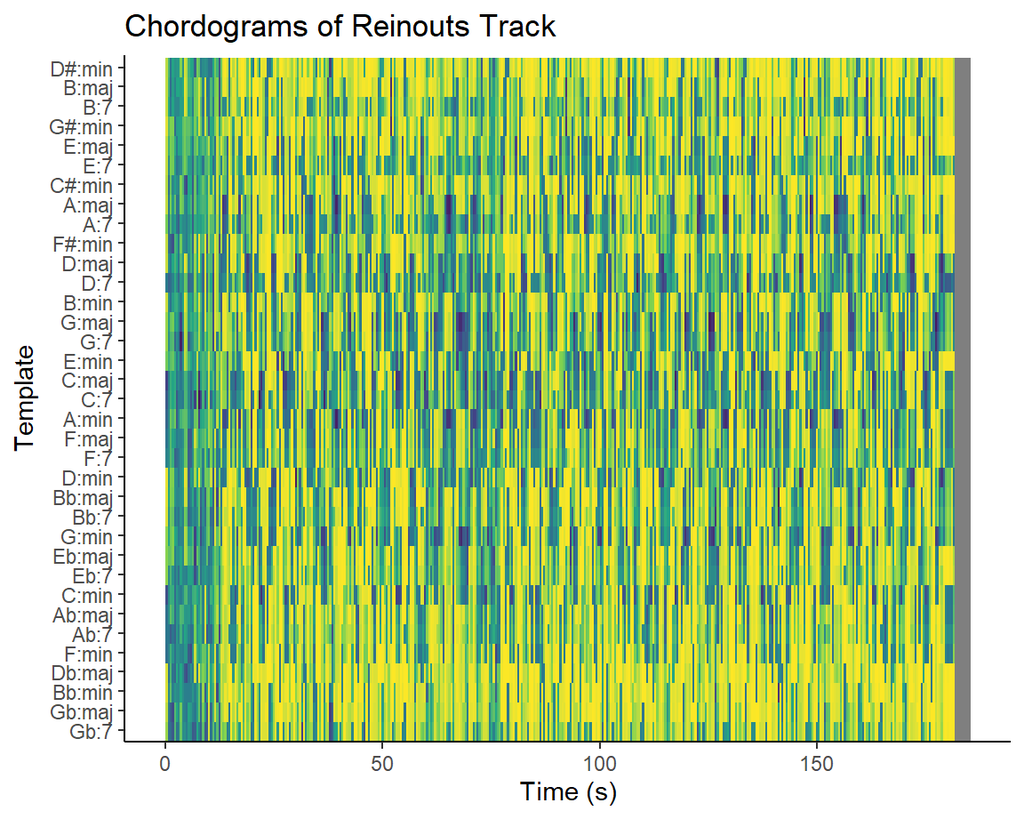

These chordograms displays matches with expectations of certain played chords. A template is created to represent the presence or absence of certain traits, such as chords, in a piece of music. This template indicates the amount of energy present in specific chords. The chordogram visualizes the relationship by showing how closely the audio matches the template. In the chordogram, dark blue indicates a good match, while yellow indicates a poor match, making it easier to identify which chords are most prominent in the audio. As you can see in the chordogram the chords used in the track of Lo are as expected a lot, and are mostly in E and G, while the chordogram has some difficulty making distinctions between g major and g minor, and e minor and e-flat major. Now, for Reinouts track, the chordogram has a lot of difficulty distinguishing between all the chords. There is a lot of variation in the yellows and blues, indicating variation in the chords.

### Energy-based novelty function based on Essentia’s loudness estimates of Lo’s and Reinouts track

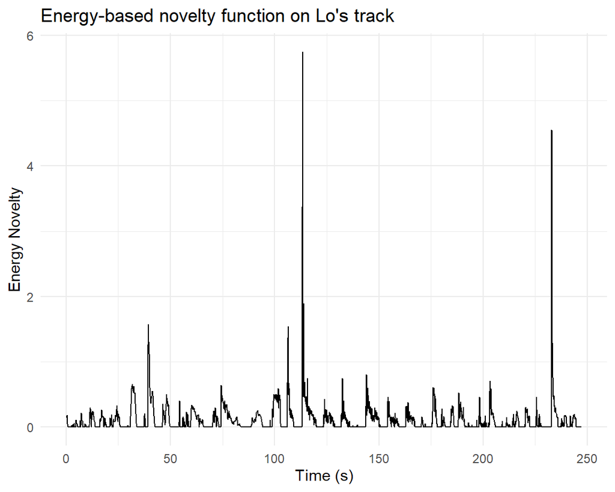

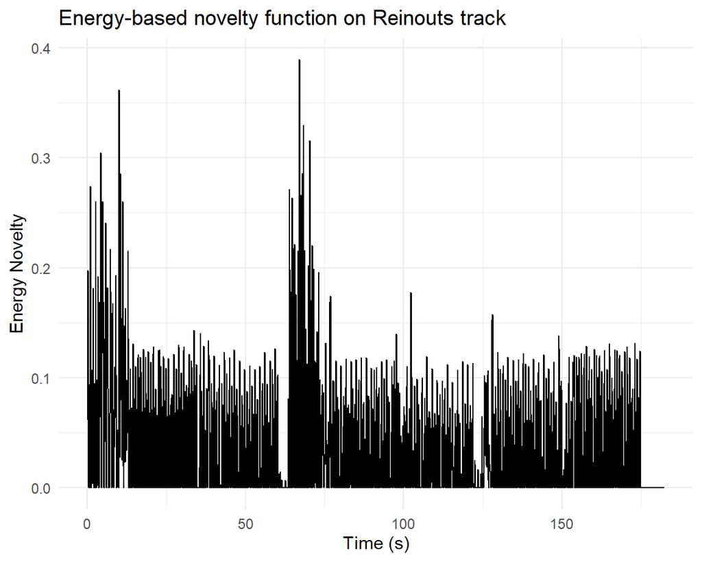

### Spectral-novelty function of Lo’s and Reinouts track

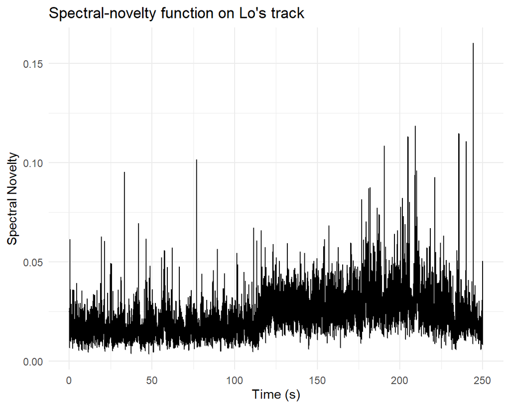

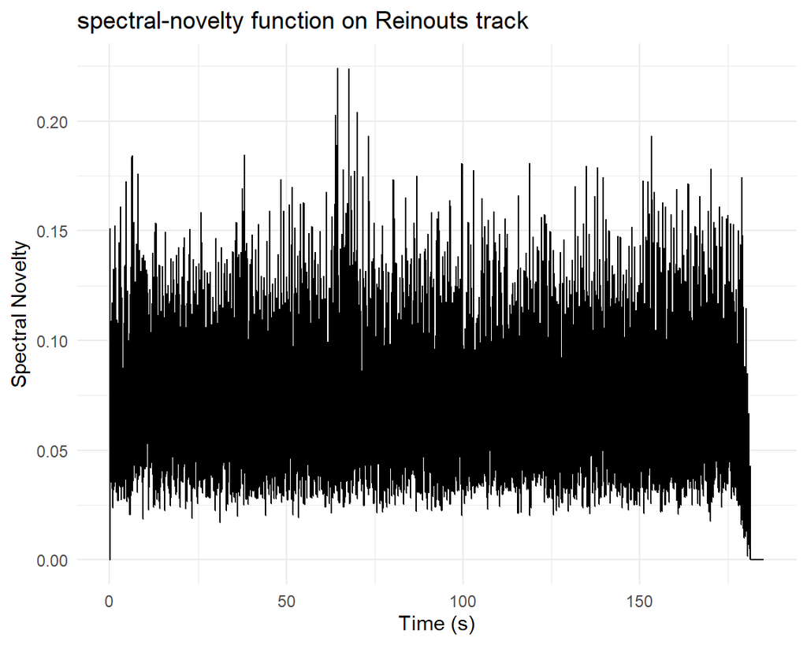

### Hierarchical clustering

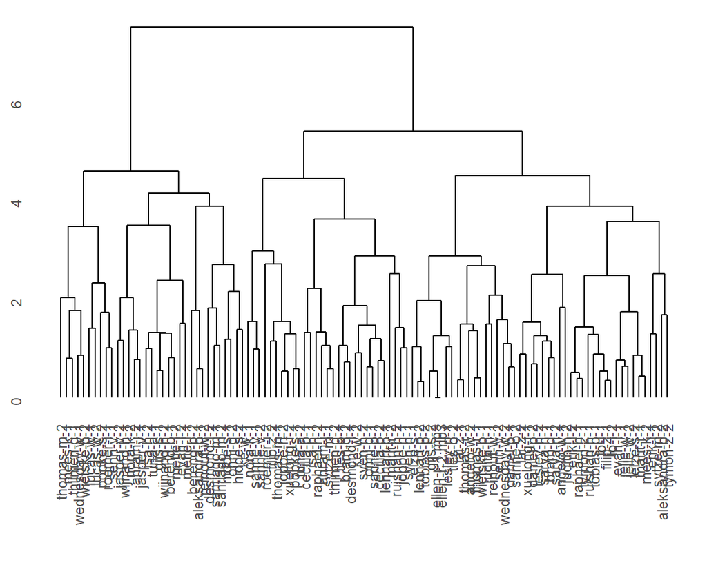